# Assignment 2, Task 2

Meghan Fletcher

2/5/2021

## Part 1: Data Visualization

```r
# Read in the data
palmetto_data <- read_csv(here("data","palmetto.csv")) %>%
  clean_names()

# Wrangle the data for visualization
palmetto_clean <- palmetto_data %>%
  dplyr::select("species", "height", "length", "width", "green_lvs") %>% mutate(species = as.factor(species)) %>%
  mutate(plant_name = case_when(
    species == 1 ~ "Serenoa repens",
    species == 2 ~ "Sabal etonia"
  )) %>%
  mutate(plant_name = fct_drop(plant_name))
```

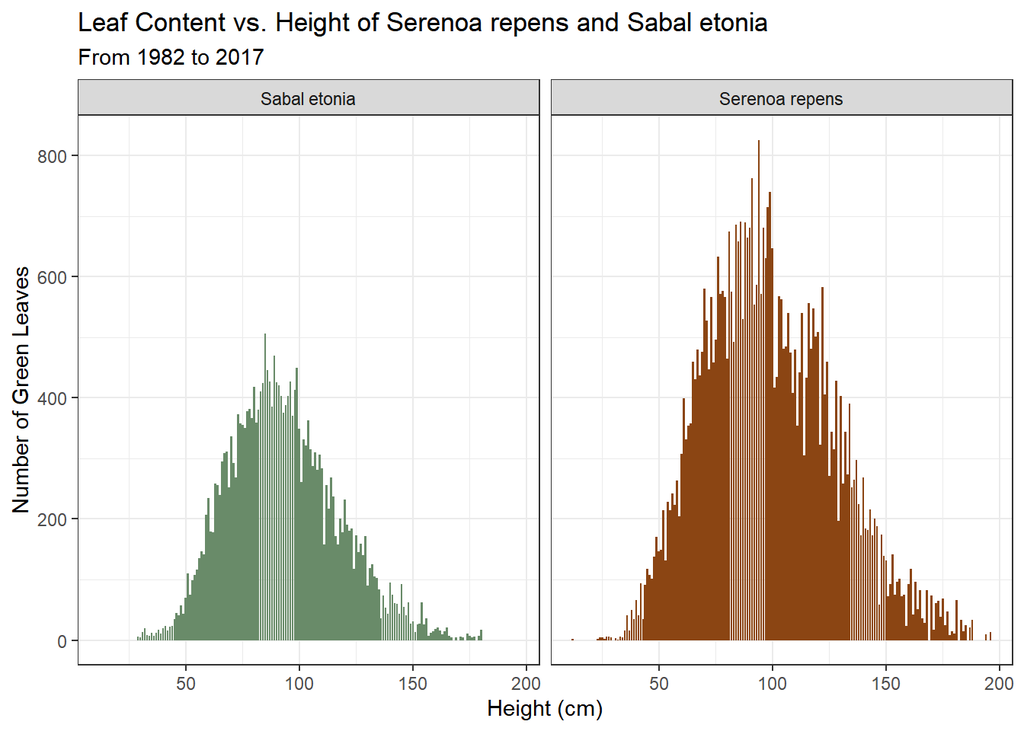

**Figure 1:** The results represent the relationship between tree height and the amount of green leaves on both *Serenoa repens* and *Sabal etonia* (Data: Abrahamson et al. 2019).

```r
# Create first visualization: height and green leaves comparison

ggplot(data = palmetto_clean, aes(x = height, y = green_lvs)) +
  geom_col(aes(fill=plant_name)) +
  facet_wrap(~ plant_name) +
  theme_bw() +
  theme(legend.position = "none") +
  labs(x = "Height (cm)", y = "Number of Green Leaves", title = "Leaf Content vs. Height of Serenoa repens and Sabal etonia", subtitle = "From 1982 to 2017") +
  scale_fill_manual(values = c("darkseagreen4", "chocolate4"))
```

#### From the graph above, we can see that both *Serenoa repens* and *Sabal etonia* appear to be similar in height (in centimaters). However, *Serenoa repens* tends to have a greater amount of green leaves. Green leaf amount appears to be greatest for trees with heights close to the mean and median values of height for both species.

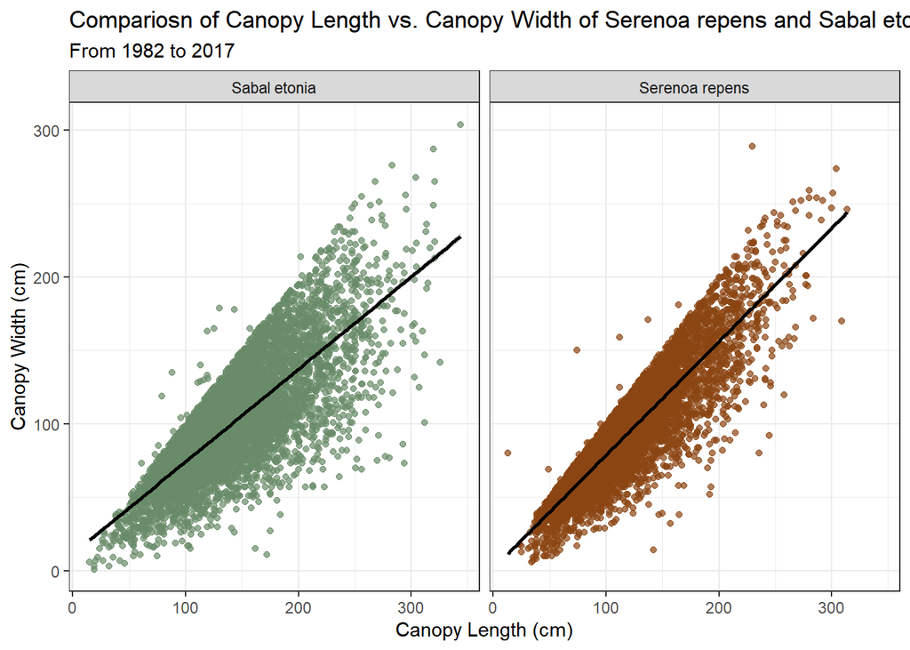

**Figure 2:** The points presented indicate that both species appear to have a strong, positive correlaiton between canopy length (cm) and canopy width (cm) (Data: Abrahamson et al. 2019).

```r
# Create a second visualization looking at the relationship between canopy width and canopy length

ggplot(data = palmetto_clean, aes(x = length, y = width)) +
  geom_point(aes(color = plant_name), alpha = 0.7) +
  scale_color_manual(values = c("darkseagreen4", "chocolate4")) +
  geom_smooth(method='lm', color = "black") +
  facet_wrap(~plant_name) +
  theme_bw() +
  theme(legend.position = "none") +
  labs(x = "Canopy Length (cm)", y = "Canopy Width (cm)", title = "Compariosn of Canopy Length vs. Canopy Width of Serenoa repens and Sabal etonia", subtitle = "From 1982 to 2017")
```

#### As canopy length (cm) increases, canopy width (cm) appears to increase almost evenly for both *Serenoa repens* and *Sabal etonia*.

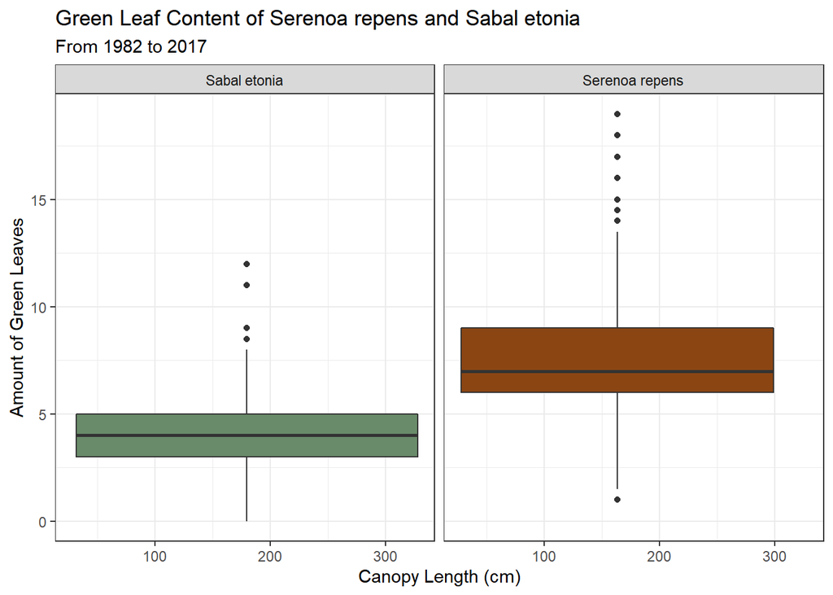

**Figure 3:** This boxplot shows us that based on the average canopy length (cm) of both species, *Serenoa repens* typically has a greater amount of green leaves present as compared to *Sabal etonia* (Data: Abrahamson et al. 2019).

```r
# Create third visualization looking at amount of green leaves by species

ggplot(data = palmetto_clean, aes(x = length, y = green_lvs)) +
  geom_boxplot(aes(fill = plant_name)) +
  facet_wrap(~plant_name) +
  theme_bw() +
  theme(legend.position = "none") +
  labs(x = "Canopy Length (cm)", y = "Amount of Green Leaves", title = "Green Leaf Content of Serenoa repens and Sabal etonia", subtitle = "From 1982 to 2017") +
  scale_fill_manual(values = c("darkseagreen4", "chocolate4"))
```

#### Based on canopy length (cm), *Serenoa repens* appears to have a greater amount of green leaves on average than *Sabal etonia*. This result may change if the amount of green leaves are based on height or canopy width.

## Part 2: Binary Logistic Regression

#### Priliminary binary logitic regression results:

```r
# create a binary logistic regression model and table
palmetto_blr <- glm(plant_name ~ height + length + width + green_lvs,
                    data = palmetto_clean,
                    family = "binomial")

summary(palmetto_blr)
```

```
##
## Call:
## glm(formula = plant_name ~ height + length + width + green_lvs,
##     family = "binomial", data = palmetto_clean)
##
## Deviance Residuals:
##     Min       1Q   Median       3Q      Max
## -4.7828  -0.2681  -0.0054   0.1725   3.3964
##
## Coefficients:
##              Estimate Std. Error z value Pr(>|z|)
## (Intercept) -3.226685   0.142071  -22.71   <2e-16 ***
## height       0.029217   0.002306   12.67   <2e-16 ***
## length      -0.045823   0.001866  -24.56   <2e-16 ***
## width       -0.039443   0.002100  -18.78   <2e-16 ***
## green_lvs    1.908475   0.038863   49.11   <2e-16 ***
## ---
## Signif. codes:  0 '***' 0.001 '**' 0.01 '*' 0.05 '.' 0.1 ' ' 1
##
## (Dispersion parameter for binomial family taken to be 1)
##
##     Null deviance: 17005.5  on 12266  degrees of freedom
## Residual deviance:  5184.6  on 12262  degrees of freedom
##   (193 observations deleted due to missingness)
## AIC: 5194.6
##
## Number of Fisher Scoring iterations: 7
```

##### **Table 1:** The data presented depicts the preliminary results from a binary logitic regression model performed on the Palmetto data where *Serenoa repens* and *Sabal etonia* are the plant species and the four predictor variables used are plant height (cm), canopy length (cm), canopy width (cm) and amount of green leaves present (Data: Abrahamson et al. (2019)).

```r
# Tidy up the data and create a table
palmetto_blr_tidy <- tidy(palmetto_blr)

palmetto_blr_tidy %>%
  kbl(caption = "Palmetto Binary Logistic Regression Model Results") %>%
   kable_classic_2(full_width = F, html_font = "Cambria")
```

Palmetto Binary Logistic Regression Model Results

| term | estimate | std.error | statistic | p.value |
| --- | --- | --- | --- | --- |
| (Intercept) | -3.2266851 | 0.1420708 | -22.71180 | 0 |
| height | 0.0292173 | 0.0023061 | 12.66984 | 0 |
| length | -0.0458233 | 0.0018661 | -24.55600 | 0 |
| width | -0.0394434 | 0.0021000 | -18.78227 | 0 |
| green_lvs | 1.9084747 | 0.0388634 | 49.10728 | 0 |

## Part 3: Finding the Probability of Predicting the Correct Plant Species using BLR

```r
palmetto_blr_fitted <- palmetto_blr %>%
  broom::augment(type.predict = "response")
```

##### **Table 2:** The results display the correctness of the binary logistic regression model used. The percentages of *Serenoa repens* and *Sabal etonia* that were successfully and unsuccessfully predicted by the model based on the four predictor variables are displayed as well, including the actual number of each outcome in parantheses (Data: Abrahamson et al. (2019)).

```r
# Create a fitted table
palmetto_fitted_table <- palmetto_blr_fitted %>%
  mutate(Predicted = case_when(
    .fitted > .50 ~ "Serenoa repens",
    .fitted <= .50 ~ "Sabal etonia"
  ))

palmetto_final <- palmetto_fitted_table %>%
  mutate(Correct = case_when(Predicted == plant_name ~ "Plants Successfully Predicted",
                             TRUE ~ "Plants Unsuccessfully Predicted")) %>%
  select(plant_name, .fitted, Predicted, Correct) %>%
  group_by(plant_name, Correct) %>%
  summarize(Results = n()) %>%
  pivot_wider(plant_name, names_from = "Correct",
              values_from = "Results") %>%
  adorn_percentages() %>%
  adorn_pct_formatting(digits = 2) %>%
  adorn_ns() %>%
  rename("Plant Species" = plant_name)

palmetto_final %>%
  kbl(caption = "Palmetto Plant Species BInary Logitic Regression Prediction Outcomes") %>%
   kable_classic_2(full_width = F, html_font = "Cambria")
```

Palmetto Plant Species BInary Logitic Regression Prediction Outcomes

| Plant Species | Plants Successfully Predicted | Plants Unsuccessfully Predicted |
| --- | --- | --- |
| Sabal etonia | 92.62% (5701) | 7.38% (454) |
| Serenoa repens | 90.77% (5548) | 9.23% (564) |

#### Overall, the BLR model used did a decent job at predicting the correct plant speices the majority of the time.

#### **Data citation:** Abrahamson, W.G. 2019. Survival, growth and biomass estimates of two dominant palmetto species of south-central Florida from 1981 - 2017, ongoing at 5-year intervals ver 1. Environmental Data Initiative. https://doi.org/10.6073/pasta/f2f96ec76fbbd4b9db431c79a770c4d5